# Notes for 2-26

## Conditionally Poisson?

- Does it make sense to use a Poisson model for counts conditional on random effects?
- Impression of the literature:
  - Early identification of overdispersion
  - Popular methods use NB
  - NB is more flexible, so doesn’t need much justification
- How would we check if Poisson was adequate after conditioning on random effects?
- Naive idea: use AIC to compare NB and Poisson GLM

### Simple simulation

- Two treatments
- Paired samples

Mean model for each count:

$$log(\mu_{gi}) = x_i^T\beta_g + z_i^T u_g + log(S_i)$$
Then $y_{gi} \sim NB(\mu_{gi}, \phi_g)$ or $y_{gi} \sim Pois(\mu_{gi})$; each simulated data set uses either NB or Pois.

Naive procedure:

- Estimate the $S_i$ before model fitting and treat as offsets
- Fit either Poisson GLMs or NB GLMs to each row
- Compare AIC between the two fits for each row

Fit GLMs using this formula:

```r
formula(y ~ trt + pairs + offset(log_S))
```

Preferred model when counts are truly NB distributed, conditional on pair effects (out of 100):

```
  nb pois
  96    4
```

Preferred model when counts are truly Poisson distributed, conditional on pair effects (out of 100):

```
pois
 100
```

Aside: if the model doesn’t include the pair effects, in other words if the model is fit with this formula:

```r
formula(y ~ trt + offset(log_S))
```

Then the NB model is generally preferred no matter the true conditional response distribution (which I think makes sense).

### KIRC data

The KIRC kidney data set includes 36 pairs of samples (tumor and non-tumor). I repeated the procedure described above on 1000 genes from this data set. The negative binomial GLM has lower AIC for all 1000 of these genes.

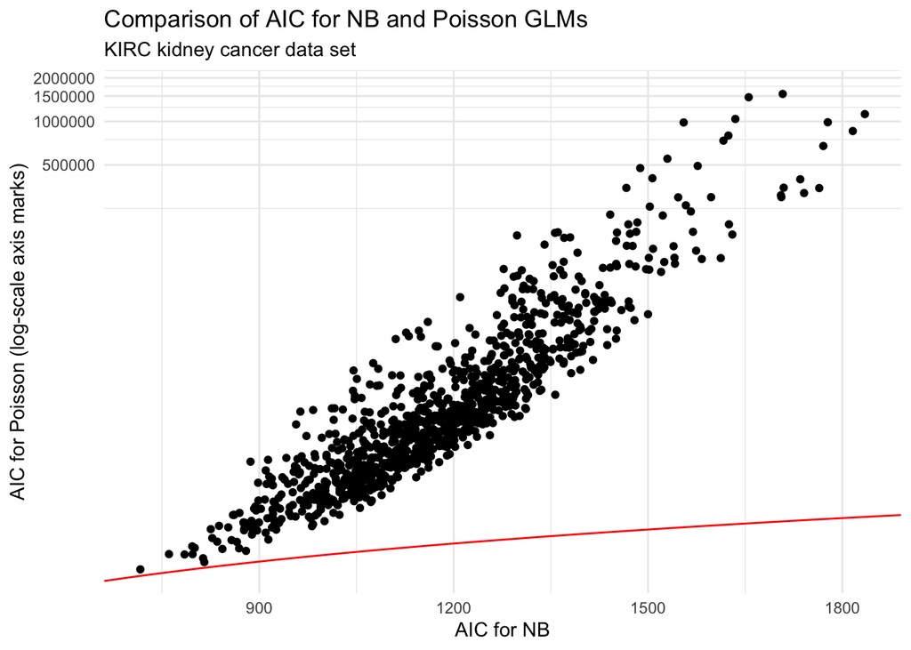

## Extra

Papers that are referenced for overdispersion (not a complete list - I quit grabbing links for these):

- [Baggerly 1](https://pmc.ncbi.nlm.nih.gov/articles/PMC524524/)
- [Lu](https://pmc.ncbi.nlm.nih.gov/articles/PMC1189357/)